# Prediction Assignment

Emilio Blanco

March 17, 2017

The goal of your project is to predict the manner in which they did the exercise. This is the “classe” variable in the training set. You may use any of the other variables to predict with. You should create a report describing how you built your model, how you used cross validation, what you think the expected out of sample error is, and why you made the choices you did. You will also use your prediction model to predict 20 different test cases.

## Reproducibility

```r
##import used libraries
library(caret)
```

```r
library(rpart)
library(rpart.plot)
library(randomForest)
set.seed(123123)
```

## Loading and Cleaning Data

```r
##Create directory if it doesnt exists
if(!file.exists("./datafolder")){
    dir.create("./datafolder")
    }
trainUrl <- "https://d396qusza40orc.cloudfront.net/predmachlearn/pml-training.csv"
testUrl <- "https://d396qusza40orc.cloudfront.net/predmachlearn/pml-testing.csv"

## add if working on Mac OS (,method="curl")
download.file(trainUrl,destfile="./datafolder/pmltraining.csv")
download.file(testUrl,destfile="./datafolder/pmltesting.csv")

trainDf <- read.csv("./datafolder/pmltraining.csv", header = TRUE, na.strings=c("NA","#DIV/0!",""))
testDf <- read.csv("./datafolder/pmltesting.csv", header = TRUE, na.strings=c("NA","#DIV/0!",""))

##Removing the unnecessary columns from both data sets such as user name and timestamps.
trainDf <- trainDf[, -c(1:7)]
testDf <- testDf[, -c(1:7)]

##Delete empty columns from data set
trainDf <- trainDf[,colSums(is.na(trainDf))==0]
testDf <- testDf[,colSums(is.na(testDf))==0]
```

**Data Partitioning**

We will partition our training data set in order to create the model ana make some tests. 75% for training and 25% for test based on the classe variable.

```r
inTrain <- createDataPartition(y=trainDf$classe, p=0.75, list = FALSE)
trainPart <- trainDf[inTrain,]
testPart <- trainDf[-inTrain,]
dim(trainPart)
```

```
## [1] 14718    53
```

```r
dim(testPart)
```

```
## [1] 4904   53
```

## Model Creation

First we start creating a classification tree model based on the type of data we have, we would like to test the prediction based on new data.

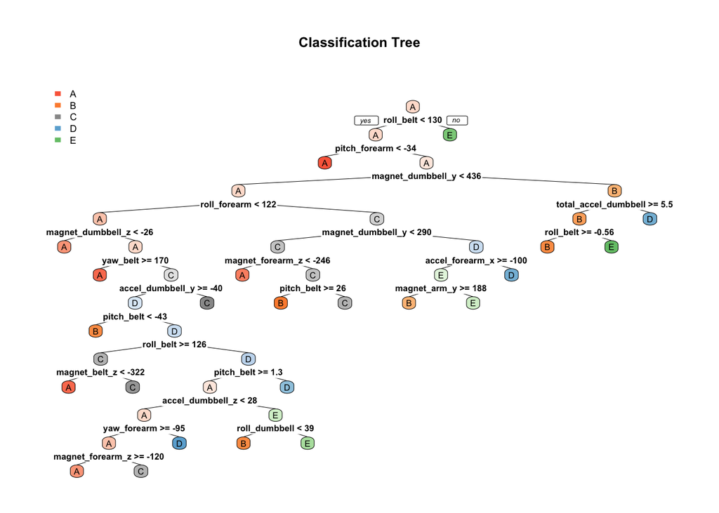

```r
##Model Creation
classTreeModel <- rpart(classe ~ ., method = "class", data = trainPart)

##Prediction Model
classTreePredict <- predict(classTreeModel, testPart, type = "class")
##Plot
rpart.plot(classTreeModel, main="Classification Tree", extra = 0, fallen.leaves = FALSE)
```

```r
##Confusion Matrix test
confusionMatrix(classTreePredict, testPart$classe)
```

```
## Confusion Matrix and Statistics
##
##           Reference
## Prediction    A    B    C    D    E
##          A 1240  185   22   84   41
##          B   36  563   69   31   72
##          C   43   98  697  133  106
##          D   58   62   47  503   46
##          E   18   41   20   53  636
##
## Overall Statistics
##
##                Accuracy : 0.742
##                  95% CI : (0.7296, 0.7542)
##     No Information Rate : 0.2845
##     P-Value [Acc > NIR] : < 2.2e-16
##
##                   Kappa : 0.6724
##  Mcnemar's Test P-Value : < 2.2e-16
##
## Statistics by Class:
##
##                      Class: A Class: B Class: C Class: D Class: E
## Sensitivity            0.8889   0.5933   0.8152   0.6256   0.7059
## Specificity            0.9054   0.9474   0.9061   0.9480   0.9670
## Pos Pred Value         0.7888   0.7302   0.6472   0.7025   0.8281
## Neg Pred Value         0.9535   0.9066   0.9587   0.9281   0.9359
## Prevalence             0.2845   0.1935   0.1743   0.1639   0.1837
## Detection Rate         0.2529   0.1148   0.1421   0.1026   0.1297
## Detection Prevalence   0.3206   0.1572   0.2196   0.1460   0.1566
## Balanced Accuracy      0.8971   0.7703   0.8607   0.7868   0.8365
```

From this model we get a 74% accuracy.

**Random Forest Model**

We continue to create a new model to classify our variables.

```r
## Random Forest Model Creation
randomForModel <- randomForest(classe ~., method="class", data = trainPart)

##Prediction Model
randomForPredict <- predict(randomForModel, testPart, type="class")

##Confusion Testing
confusionMatrix(randomForPredict, testPart$classe)
```

```
## Confusion Matrix and Statistics
##
##           Reference
## Prediction    A    B    C    D    E
##          A 1395    4    0    0    0
##          B    0  944    3    0    0
##          C    0    1  852    4    0
##          D    0    0    0  800    1
##          E    0    0    0    0  900
##
## Overall Statistics
##
##                Accuracy : 0.9973
##                  95% CI : (0.9955, 0.9986)
##     No Information Rate : 0.2845
##     P-Value [Acc > NIR] : < 2.2e-16
##
##                   Kappa : 0.9966
##  Mcnemar's Test P-Value : NA
##
## Statistics by Class:
##
##                      Class: A Class: B Class: C Class: D Class: E
## Sensitivity            1.0000   0.9947   0.9965   0.9950   0.9989
## Specificity            0.9989   0.9992   0.9988   0.9998   1.0000
## Pos Pred Value         0.9971   0.9968   0.9942   0.9988   1.0000
## Neg Pred Value         1.0000   0.9987   0.9993   0.9990   0.9998
## Prevalence             0.2845   0.1935   0.1743   0.1639   0.1837
## Detection Rate         0.2845   0.1925   0.1737   0.1631   0.1835
## Detection Prevalence   0.2853   0.1931   0.1748   0.1633   0.1835
## Balanced Accuracy      0.9994   0.9970   0.9976   0.9974   0.9994
```

The results were improved using the Random Forest Model with a 99% of accuracy.

## Final Prediction

```r
finalPredictioRF <- predict(randomForModel, testDf, type = "class")
##The results for the quizz comes below
finalPredictioRF
```

```
##  1  2  3  4  5  6  7  8  9 10 11 12 13 14 15 16 17 18 19 20
##  B  A  B  A  A  E  D  B  A  A  B  C  B  A  E  E  A  B  B  B
## Levels: A B C D E
```